# Soil Waterlogging

# 5.4 Probabilistic Predictions

I chose the threshold for converting predicted probabilities into binary classifications by analysing the ROC curve. This allowed me to adjust the balance between sensitivity and specificity depending on the scenario. For critical infrastructure, where overlooking a waterlogged site could have serious consequences, a lower threshold (0.3) was selected to maximise sensitivity. Conversely, for non-critical infrastructure, where false alarms are more costly, a higher threshold (0.7) was chosen to maximise specificity. Predicted probabilities of waterlogging at 100 cm were generated for validation points.

```r
auc_prob <- readRDS(here::here("data/eval_prob_auc.rds"))
threshold_results <- readRDS(here::here("data/eval_prob_thresholds.rds"))
```

```r
knitr::kable(
  auc_prob,
  digits = 3,
  caption = "AUC of the probabilistic Random Forest model."
)
```

AUC of the probabilistic Random Forest model.

| Model | AUC |
| --- | --- |
| Probabilistic RF | 0.809 |

- **Critical infrastructure**: Lowering the threshold increased **sensitivity** to 0.81 (most waterlogged sites detected) but reduced **specificity** to 0.65.
- **Non-critical infrastructure**: Raising the threshold decreased **sensitivity** to 0.34 but increased **specificity** to 0.94.

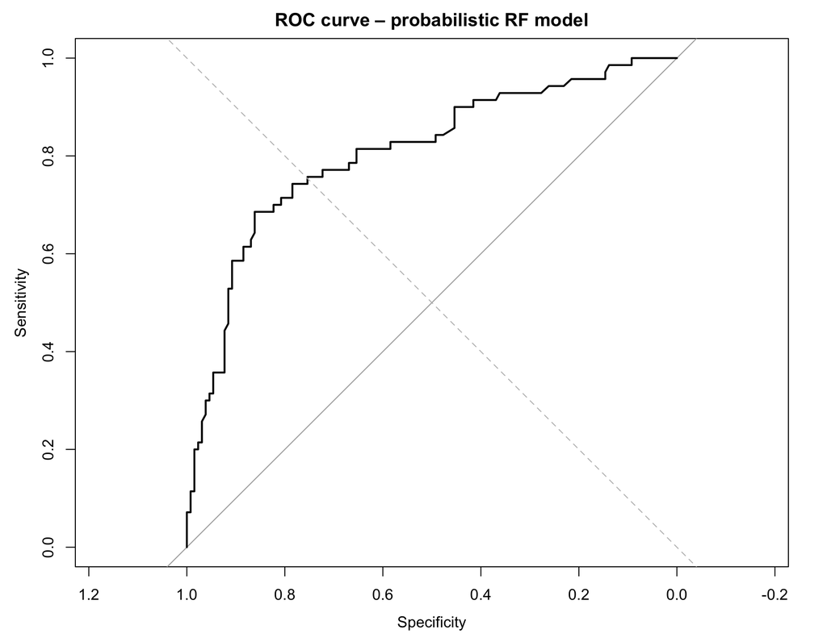

ROC curve of the probabilistic Random Forest model.

The model was evaluated separately for the two scenarios using the chosen thresholds. In the critical infrastructure scenario, sensitivity increased to 0.81 while specificity decreased to 0.65, indicating a deliberate bias towards identifying waterlogged sites. In the non-critical infrastructure scenario, sensitivity decreased to 0.34, but specificity increased to 0.94, demonstrating the model’s capacity to minimise false positives even if some waterlogged sites are overlooked. These results demonstrate that selecting different thresholds can be used to tailor model outputs according to the consequences of misclassification.

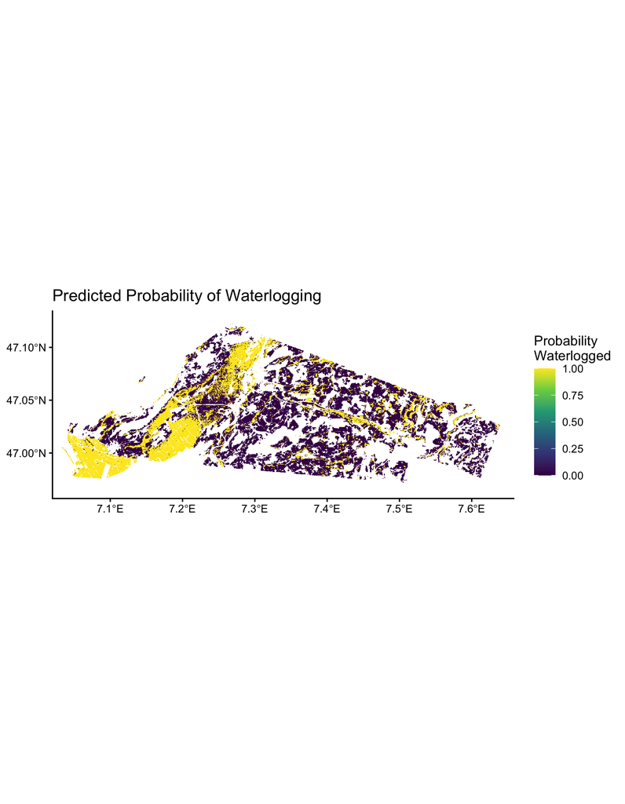

Predicted probability of waterlogging (0–100 cm) using the tuned Random Forest model.

```r
map_summary <- readRDS(here("data/map_summary_tuned_rf.rds"))

data.frame(
  Minimum = map_summary$min_prob,
  Mean    = map_summary$mean_prob,
  Maximum = map_summary$max_prob
) |> knitr::kable(digits = 3)
```

[output not shown]

The map highlights spatial patterns in soil waterlogging and shows that some regions have higher probabilities, which are likely influenced by underlying environmental factors such as soil type, topography and hydrology.

In practice, this map provides a spatially explicit risk assessment, guiding decision-making in construction planning or land management by identifying areas more likely to be waterlogged.